# Exploring the Multilevel Impact of Information and Communication Technology (ICT) on Reading Achievement: A Hierarchical Analysis of Student, Home, and School Factors from the PISA 2018 Assessment

Nirmal Ghimire, K-16 Literacy Center

2024-08-26

## Introduction

Information and communication technologies (ICT) have become increasingly integrated into education systems around the world. However, access to and use of ICT varies greatly between countries and schools. The 2018 PISA assessment provides a unique opportunity to examine how ICT factors relate to student reading achievement across countries, students’ access to ICT devices, their usage, and confidence using them.

### Research Questions

Here are the research questions.

- **Student and Home Environment Impact**: How do individual access to ICT devices at home (ICTHOME), perceived competence in ICT (COMPICT), interest in ICT (INTICT), and use of ICT for school-related tasks at home (HOMESCH) and outside school (ICTOUTSIDE) relate to reading scores (PV1READ-PV10READ) among students?
- **School-level Influence**: What are the relationships between school-level factors such as ICT infrastructure (ICTSCH), resources (ICTRES), classroom use (ICTCLASS), and entrepreneurship tasks involving ICT (ENTUSE) on reading achievement within schools?
- **Cross-Level Interactions**: How do student-level ICT variables interact with school-level factors to collectively influence reading achievement, and how do these relationships manifest across different countries?

## Student Reading Assessment Data

```
[1] 612004     27
```

```
 [1] "CNTRYID"    "CNT"        "CNTSCHID"   "CNTSTUID"   "OECD"
 [6] "ICTHOME"    "ICTSCH"     "ICTRES"     "ENTUSE"     "HOMESCH"
[11] "USESCH"     "INTICT"     "COMPICT"    "AUTICT"     "ICTCLASS"
[16] "ICTOUTSIDE" "W_FSTUWT"   "PV1READ"    "PV2READ"    "PV3READ"
[21] "PV4READ"    "PV5READ"    "PV6READ"    "PV7READ"    "PV8READ"
[26] "PV9READ"    "PV10READ"
```

## Variable Information

- *OECD* - Indicator for OECD membership, dichotomous variable with 0 representing non OECD countries and 1 representing OECD countries.
- *ICTHOME* - Index of ICT availability at home, continuous variable ranging from 0-11.
- *ICTSCH* - Index of school’s ICT infrastructure, continuous variable ranging from 0-10.
- *ICTRES* - ICT resources at school, continuous standardized index.
- *ENTUSE* - Use of ICT for entrepreneurship tasks at school, continuous standardized index.
- *HOMESCH* - Use of ICT for school-related tasks at home, continuous standardized index.
- *USESCH* - Use of ICT at school, continuous standardized index.
- *INTICT* - Interest in ICT, continuous standardized index.
- *COMPICT* - Perceived ICT competence, continuous standardized index.
- *AUTICT* - Perceived autonomy in using ICT, continuous standardized index.
- *ICTCLASS* - Use of ICT in classroom, continuous standardized index.
- *ICTOUTSIDE* - Use of ICT outside of school, continuous standardized index.
- *W_FSTUWT* - Student final weight, continuous variable.
- *PV1READ-PV10READ* - Plausible values for reading, continuous variables (10 total).

OECD. (2019). PISA 2018 Technical Report. https://www.oecd.org/pisa/data/pisa2018technicalreport/

## Run Weighted Linear Regression for Country Reading Scores

The intercept, or the reference country is Albania

```
   Estimate Std..Error t.value Pr...t..
1    405.43       3.77  107.64   0.0000
2     26.35       4.63    5.69   0.0000
3     -3.93       3.86   -1.02   0.3108
4     97.20       3.97   24.51   0.0000
5     78.96       4.41   17.90   0.0000
6     87.44       4.19   20.87   0.0000
7     14.41       4.74    3.04   0.0025
8     -2.45       5.29   -0.46   0.6435
9     68.36       4.39   15.58   0.0000
10     7.44       3.79    1.96   0.0509
11     2.64       8.47    0.31   0.7557
12   114.66       3.92   29.25   0.0000
13    78.50       4.44   17.68   0.0000
14    46.84       4.01   11.70   0.0000
```

[output cut: 65 more lines]

## Student and Home Environment Impact

```
  Estimate Std..Error t.value      Pr...t..
1   473.32       5.91   80.02  1.709706e-57
2     0.82       0.08   10.30  1.962781e-20
3     5.18       0.21   24.13 1.267128e-117
4    13.26       0.20   65.40  0.000000e+00
5    -8.86       0.19  -47.33  0.000000e+00
6     6.51       0.18   36.36 6.049261e-275
```

**Findings from the Fixed Effects:**

1. Intercept (473.32): This represents the average reading score for the reference group, considering all other variables are zero. Essentially, it’s a baseline score.
2. ICTHOME (0.82): For every one-unit increase in the Index of ICT availability at home, reading scores are estimated to increase by 0.82 points, *t*(606548)= 10.30, *p* < .001.
3. COMPICT (5.18): For every one-unit increase in perceived ICT competence, reading scores are estimated to increase by 5.18 points, *t*(606548)= 24.13, *p* < .001.
4. INTICT (13.26): For every one-unit increase in interest in ICT, reading scores are estimated to increase by 13.26 points,*t*(606548) = 65.40, *p* < .001.
5. HOMESCH (-8.86): For every one-unit increase in the use of ICT for school-related tasks at home, reading scores are estimated to decrease by 8.86 points, *t*(606548) = −47.33, *p* < .001.
6. ICTOUTSIDE (6.51): For every one-unit increase in the use of ICT outside of school, reading scores are estimated to increase by 6.51 points, *t*(606548) = 36.36, *p* < .001.

```
Linear mixed model fit by REML. t-tests use Satterthwaite's method [
lmerModLmerTest]
Formula: formula
   Data: student_data
Weights: student_data$W_FSTUWT

REML criterion at convergence: 3769841

Scaled residuals:
     Min       1Q   Median       3Q      Max
-17.8105  -0.3051   0.0165   0.3403  17.9388

Random effects:
 Groups   Name        Variance Std.Dev.
 CNTRYID  (Intercept)   1807    42.51
 Residual             391782   625.92
Number of obs: 287246, groups:  CNTRYID, 52

Fixed effects:
                Estimate   Std. Error           df t value            Pr(>|t|)
(Intercept)    472.59317      5.95699     52.36523   79.33 <0.0000000000000002
ICTHOME          0.90090      0.07994 287237.33183   11.27 <0.0000000000000002
COMPICT          4.93788      0.21500 287200.12998   22.97 <0.0000000000000002
INTICT          13.34080      0.20290 287208.15639   65.75 <0.0000000000000002
HOMESCH         -8.66784      0.18740 287222.92913  -46.25 <0.0000000000000002
ICTOUTSIDE       6.53234      0.17912 287216.09032   36.47 <0.0000000000000002

(Intercept) ***
ICTHOME     ***
COMPICT     ***
INTICT      ***
HOMESCH     ***
ICTOUTSIDE  ***
---
Signif. codes:  0 '***' 0.001 '**' 0.01 '*' 0.05 '.' 0.1 ' ' 1

Correlation of Fixed Effects:
           (Intr) ICTHOM COMPIC INTICT HOMESC
ICTHOME    -0.106
COMPICT     0.009 -0.082
INTICT      0.000  0.009 -0.497
HOMESCH     0.015 -0.169 -0.120 -0.115
ICTOUTSIDE  0.007 -0.068 -0.002 -0.030 -0.223
```

**Random Effects:**

1. Country Level (CNTRYID): The variance at the country level is 1807, with a standard deviation of 42.51. This shows that there is significant variability in the intercepts between countries, representing differences in average reading scores that are not accounted for by the observed variables.
2. Residual: The residual variance is 391782, with a standard deviation of 625.92, representing the variability within countries not explained by the model.

**Conclusion:** The results of this model provide robust evidence for the relationships between various ICT-related factors and reading achievement among students. The model accounts for the hierarchical structure of the data, acknowledging that students are nested within countries. The significant random intercept for countries emphasizes the importance of considering country-level differences when examining these relationships.

### Performance Matrices for Student-Home Model

```
[[1]]
# Indices of model performance

AIC       |      AICc |       BIC | R2 (cond.) | R2 (marg.) |   ICC |   RMSE |   Sigma
--------------------------------------------------------------------------------------
3.770e+06 | 3.770e+06 | 3.770e+06 |      0.005 |  8.498e-04 | 0.005 | 91.581 | 626.394

[[2]]
# Indices of model performance

AIC       |      AICc |       BIC | R2 (cond.) | R2 (marg.) |   ICC |   RMSE |   Sigma
--------------------------------------------------------------------------------------
3.769e+06 | 3.769e+06 | 3.769e+06 |      0.005 |  8.671e-04 | 0.005 | 91.464 | 624.616

[[3]]
# Indices of model performance

AIC       |      AICc |       BIC | R2 (cond.) | R2 (marg.) |   ICC |   RMSE |   Sigma
--------------------------------------------------------------------------------------
3.769e+06 | 3.769e+06 | 3.769e+06 |      0.005 |  8.706e-04 | 0.005 | 91.594 | 625.233

[[4]]
# Indices of model performance

AIC       |      AICc |       BIC | R2 (cond.) | R2 (marg.) |   ICC |   RMSE |   Sigma
--------------------------------------------------------------------------------------
3.770e+06 | 3.770e+06 | 3.770e+06 |      0.005 |  8.653e-04 | 0.005 | 91.560 | 625.877

[[5]]
# Indices of model performance

AIC       |      AICc |       BIC | R2 (cond.) | R2 (marg.) |   ICC |   RMSE |   Sigma
--------------------------------------------------------------------------------------
3.770e+06 | 3.770e+06 | 3.770e+06 |      0.005 |  8.249e-04 | 0.005 | 91.533 | 625.824

[[6]]
# Indices of model performance

AIC       |      AICc |       BIC | R2 (cond.) | R2 (marg.) |   ICC |   RMSE |   Sigma
--------------------------------------------------------------------------------------
```

[output cut: 14 more lines]

```
3.769e+06 | 3.769e+06 | 3.769e+06 |      0.005 |  8.486e-04 | 0.005 | 91.530 | 624.823

[[9]]
# Indices of model performance

AIC       |      AICc |       BIC | R2 (cond.) | R2 (marg.) |   ICC |   RMSE |   Sigma
--------------------------------------------------------------------------------------
3.768e+06 | 3.768e+06 | 3.768e+06 |      0.005 |  8.190e-04 | 0.005 | 91.480 | 624.036

[[10]]
# Indices of model performance

AIC       |      AICc |       BIC | R2 (cond.) | R2 (marg.) |   ICC |   RMSE |   Sigma
--------------------------------------------------------------------------------------
3.770e+06 | 3.770e+06 | 3.770e+06 |      0.005 |  8.397e-04 | 0.004 | 91.539 | 625.919
```

## School-level Influence

**Differences Between Schools:** The random effect (1|CNTSCHID) in your model accounts for the unobserved heterogeneity between different schools within countries. Essentially, it captures the variability in reading scores that is attributable to differences between schools. If this random effect is statistically significant, it would suggest that the reading scores vary between schools, even after accounting for the observed predictors in your model.

**Results About Students or Schools:** The fixed effects (e.g., ICTSCH, ICTRES, ICTCLASS, ENTUSE) provide insights into the relationships between the school-level variables and student reading achievement, controlling for the nested structure of the data.

In the context of this analysis, the coefficients for the fixed effects represent the average impact of the corresponding school-level variable on individual student reading scores, taking into account the clustering of students within schools. Thus, the results provide insights into how school-level factors influence student outcomes, as well as the variation between schools in these relationships.

```
  Estimate Std..Error t.value     Pr...t..
1   490.99       0.74  663.93 0.000000e+00
2    -3.13       0.06  -50.12 0.000000e+00
3     8.76       0.16   53.64 0.000000e+00
4    -1.24       0.17   -7.41 3.280031e-10
5     0.27       0.13    2.00 8.696619e-02
```

```
Linear mixed model fit by REML. t-tests use Satterthwaite's method [
lmerModLmerTest]
Formula: formula
   Data: student_data
Weights: student_data$W_FSTUWT

REML criterion at convergence: 4091812

Scaled residuals:
     Min       1Q   Median       3Q      Max
-20.9633  -0.3155   0.0077   0.3337  18.7423

Random effects:
 Groups   Name        Variance Std.Dev.
 CNTSCHID (Intercept)   3736    61.13
 Residual             276220   525.57
Number of obs: 318337, groups:  CNTSCHID, 13603

Fixed effects:
                Estimate   Std. Error           df t value             Pr(>|t|)
(Intercept)    490.98071      0.73942  25174.15466 664.008 < 0.0000000000000002
ICTSCH          -3.13854      0.06243 313734.70478 -50.273 < 0.0000000000000002
ICTRES           8.79637      0.16310 318097.19644  53.932 < 0.0000000000000002
ICTCLASS        -1.23535      0.16681 315876.75366  -7.406    0.000000000000131
ENTUSE           0.19017      0.13365 310837.09666   1.423                0.155

(Intercept) ***
ICTSCH      ***
ICTRES      ***
ICTCLASS    ***
ENTUSE
---
Signif. codes:  0 '***' 0.001 '**' 0.01 '*' 0.05 '.' 0.1 ' ' 1

Correlation of Fixed Effects:
         (Intr) ICTSCH ICTRES ICTCLA
ICTSCH   -0.534
ICTRES    0.146 -0.133
ICTCLASS  0.064 -0.107 -0.031
ENTUSE    0.019 -0.059 -0.155 -0.072
optimizer (nloptwrap) convergence code: 0 (OK)
Model is nearly unidentifiable: very large eigenvalue
 - Rescale variables?
```

**Random Effects:**

1. School Level (CNTSCHID): The variance at the school level is 3736, with a standard deviation of 61.13. This shows substantial variability in the intercepts between schools, representing differences in average reading scores that are not accounted for by the observed variables.
2. Residual: The residual variance is 276220, with a standard deviation of 525.57, representing the variability within schools not explained by the model.

**Conclusion:** The results provide valuable information about how school-level factors related to ICT are associated with reading achievement. The significant random intercept for schools emphasizes the importance of considering school-level differences.

### Performance Metrics for the School Model

```
[[1]]
# Indices of model performance

AIC       |      AICc |       BIC | R2 (cond.) | R2 (marg.) |   ICC |   RMSE |   Sigma
--------------------------------------------------------------------------------------
4.094e+06 | 4.094e+06 | 4.094e+06 |      0.014 |  4.122e-04 | 0.013 | 77.980 | 527.360

[[2]]
# Indices of model performance

AIC       |      AICc |       BIC | R2 (cond.) | R2 (marg.) |   ICC |   RMSE |   Sigma
--------------------------------------------------------------------------------------
4.093e+06 | 4.093e+06 | 4.093e+06 |      0.014 |  4.191e-04 | 0.013 | 77.898 | 526.331

[[3]]
# Indices of model performance

AIC       |      AICc |       BIC | R2 (cond.) | R2 (marg.) |   ICC |   RMSE |   Sigma
--------------------------------------------------------------------------------------
4.092e+06 | 4.092e+06 | 4.092e+06 |      0.014 |  3.934e-04 | 0.013 | 77.908 | 525.952

[[4]]
# Indices of model performance

AIC       |      AICc |       BIC | R2 (cond.) | R2 (marg.) |   ICC |   RMSE |   Sigma
--------------------------------------------------------------------------------------
4.093e+06 | 4.093e+06 | 4.094e+06 |      0.014 |  4.136e-04 | 0.013 | 77.940 | 526.933

[[5]]
# Indices of model performance

AIC       |      AICc |       BIC | R2 (cond.) | R2 (marg.) |   ICC |   RMSE |   Sigma
--------------------------------------------------------------------------------------
4.092e+06 | 4.092e+06 | 4.092e+06 |      0.014 |  4.208e-04 | 0.013 | 77.857 | 525.359

[[6]]
# Indices of model performance

AIC       |      AICc |       BIC | R2 (cond.) | R2 (marg.) |   ICC |   RMSE |   Sigma
--------------------------------------------------------------------------------------
```

[output cut: 14 more lines]

```
4.092e+06 | 4.092e+06 | 4.092e+06 |      0.014 |  4.236e-04 | 0.013 | 77.928 | 526.112

[[9]]
# Indices of model performance

AIC       |      AICc |       BIC | R2 (cond.) | R2 (marg.) |   ICC |   RMSE |   Sigma
--------------------------------------------------------------------------------------
4.091e+06 | 4.091e+06 | 4.091e+06 |      0.014 |  4.122e-04 | 0.013 | 77.882 | 525.030

[[10]]
# Indices of model performance

AIC       |      AICc |       BIC | R2 (cond.) | R2 (marg.) |   ICC |   RMSE |   Sigma
--------------------------------------------------------------------------------------
4.092e+06 | 4.092e+06 | 4.092e+06 |      0.014 |  4.194e-04 | 0.013 | 77.900 | 525.562
```

## Cross-Level Interactions

```
   Estimate Std..Error t.value
1    467.23       9.75   73.70
2      3.97       0.15   26.36
3      3.60       0.19   18.88
4      7.91       0.18   44.14
5     -8.81       0.18  -48.75
6      4.44       0.17   26.46
7      7.19       0.18   40.94
8     10.72       0.19   55.07
9     -2.00       0.19  -10.67
10     0.23       0.17    1.40
11    -1.25       0.02  -58.99
12    -0.95       0.13   -7.29
13     0.55       0.14    3.93
                                                                                                                                                    Pr...t..
1  0.0000000000000000000000000657935777971899798379981638696278878342127427458763122558593750000000000000000000000000000000000000000000000000000000000000000
2  0.0000000000000000000000000000000000000000000000000000000000000000000000000000000000000000000000000000000000000000000000000000000000000000000000502122796
3  0.0000000000000000000000000000000000000000000000000000000000000000000002222466472045133815266249044384494482073932886123657226562500000000000000000000000
4  0.0000000000000000000000000000000000000000000000000000000000000000000000000000000000000000000000000000000000000000000000000000000000000000000000000000000
5  0.0000000000000000000000000000000000000000000000000000000000000000000000000000000000000000000000000000000000000000000000000000000000000000000000000000000
6  0.0000000000000000000000000000000000000000000000000000000000000000000000000000000000000000000000000000000000000000000000000000000000000000000000002165029
7  0.0000000000000000000000000000000000000000000000000000000000000000000000000000000000000000000000000000000000000000000000000000000000000000000000000000000
8  0.0000000000000000000000000000000000000000000000000000000000000000000000000000000000000000000000000000000000000000000000000000000000000000000000000000000
9  0.0000000000000000000037316579017319015166599671662339687827625311911106109619140625000000000000000000000000000000000000000000000000000000000000000000000
10 0.2555443155230210372508281579939648509025573730468750000000000000000000000000000000000000000000000000000000000000000000000000000000000000000000000000000
11 0.0000000000000000000000000000000000000000000000000000000000000000000000000000000000000000000000000000000000000000000000000000000000000000000000000000000
12 0.0000000175688421317064823634797321449951823524315841495990753173828125000000000000000000000000000000000000000000000000000000000000000000000000000000000
13 0.0003232804967749064841212036647277727752225473523139953613281250000000000000000000000000000000000000000000000000000000000000000000000000000000000000000
```

The model also considered interaction terms such as ICTHOME:ICTSCH, COMPICT:ICTRES, and INTICT:ICTCLASS, with random effects for schools (CNTSCHID) and countries (CNTRYID).

**Findings:**

1. ICTHOME: For every one-unit increase in ICTHOME, reading scores increased by an estimated 3.97 points,*t*(2.55×10^5) = 26.36, *p* < .001.
2. COMPICT: The effect of COMPICT was positive and significant, *t*(2.23×10^5) = 18.88, *p* <.001, with an estimated increase of 3.60 points in reading scores.
3. INTICT: A significant positive effect was observed, with an increase of 7.91 points in reading scores for every one-unit increase in INTICT, *t*(2.17×10^5) = 44.14, *p* <.001.
4. HOMESCH: The use of ICT for school-related tasks at home was negatively associated with reading scores, with an estimated decrease of 8.81 points, *t*(2.17×10^5) = −48.75, *p* <.001.
5. ICTOUTSIDE: A significant positive effect was noted, with an estimated increase of 4.44 points in reading scores, *t*(2.17×10^5) = 26.46,*p* < .001.
6. ICTSCH: The effect of ICTSCH was significant and positive, with an estimated increase of 7.19 points, *t*(2.17×10^5) = 40.94,*p* <. 001.
7. ICTRES: A significant effect was observed for ICTRES, with an estimated increase of 10.72 points, *t*(2.17×10^5) = 55.06, *p* < .001.
8. ICTCLASS: A negative relationship was found with reading scores, with an estimated decrease of 2.00 points, *t*(3.81×10^5) = −10.67,*p* < .001.
9. ENTUSE: The effect of ENTUSE was not significant, *t*(2.55×10^5) = 1.40, *p* = .256.
10. **Interaction Terms:** The interaction terms showed significant effects for ICTHOME:ICTSCH, COMPICT:ICTRES, and INTICT:ICTCLASS, with the strongest effect observed for the interaction between ICTHOME and ICTSCH, *t*(2.17×10^5) = −58.99, *p* <.001.

In summary, the results indicate that both student-level and school-level variables, along with their interactions, play significant roles in influencing reading achievement. The findings highlight the importance of considering cross-level interactions in understanding the complexities of ICT usage and reading outcomes.

```
Linear mixed model fit by REML. t-tests use Satterthwaite's method [
lmerModLmerTest]
Formula: formula
   Data: student_data
Weights: student_data$W_FSTUWT

REML criterion at convergence: 3629820

Scaled residuals:
     Min       1Q   Median       3Q      Max
-19.7015  -0.3106   0.0126   0.3319  18.4137

Random effects:
 Groups   Name        Variance Std.Dev.
 CNTSCHID (Intercept)   1897    43.56
 CNTRYID  (Intercept)   1668    40.84
 Residual             269342   518.98
Number of obs: 283367, groups:  CNTSCHID, 13497; CNTRYID, 52

Fixed effects:
                  Estimate Std. Error         df t value Pr(>|t|)
(Intercept)      4.670e+02  5.822e+00  5.547e+01  80.220  < 2e-16 ***
ICTHOME          4.005e+00  1.506e-01  2.794e+05  26.586  < 2e-16 ***
COMPICT          3.358e+00  1.906e-01  2.767e+05  17.611  < 2e-16 ***
INTICT           8.009e+00  1.793e-01  2.773e+05  44.672  < 2e-16 ***
HOMESCH         -8.570e+00  1.806e-01  2.786e+05 -47.451  < 2e-16 ***
ICTOUTSIDE       4.452e+00  1.679e-01  2.778e+05  26.522  < 2e-16 ***
ICTSCH           7.086e+00  1.757e-01  2.798e+05  40.330  < 2e-16 ***
ICTRES           1.064e+01  1.946e-01  2.798e+05  54.644  < 2e-16 ***
ICTCLASS        -2.013e+00  1.878e-01  2.803e+05 -10.719  < 2e-16 ***
ENTUSE           1.123e-01  1.653e-01  2.780e+05   0.679 0.496978
ICTHOME:ICTSCH  -1.237e+00  2.113e-02  2.796e+05 -58.533  < 2e-16 ***
COMPICT:ICTRES  -9.533e-01  1.305e-01  2.775e+05  -7.306 2.75e-13 ***
INTICT:ICTCLASS  5.303e-01  1.401e-01  2.776e+05   3.784 0.000154 ***
---
Signif. codes:  0 '***' 0.001 '**' 0.01 '*' 0.05 '.' 0.1 ' ' 1
optimizer (nloptwrap) convergence code: 0 (OK)
Model is nearly unidentifiable: very large eigenvalue
 - Rescale variables?
```

**Random Effects:** The random effects section of the model shows the variability of the intercept across different levels of the hierarchical data structure. The variance components are:

1. School Level (CNTSCHID): The random intercept variance at the school level was estimated to be 1897, with a standard deviation of 43.56. This indicates substantial variability in reading scores across schools.
2. Country Level (CNTRYID): The random intercept variance at the country level was estimated to be 1668, with a standard deviation of 40.84. This suggests significant variability in reading scores across countries.
3. Residual: The residual variance was estimated to be 269342, with a standard deviation of 518.98, representing the unexplained variability in reading scores.

The significant random effects at both the school and country levels highlight the importance of accounting for the hierarchical structure of the data, as ignoring these effects could lead to biased estimates.

**Conclusion:** The results of the linear mixed model provide substantial evidence for the complex interplay between individual and school-level factors in predicting reading scores. The model accounted for random variations at the school and country levels, revealing significant fixed effects for most of the individual and school-level predictors, as well as important interactions.

### Performance matrices for the Cross-Level Model

```
[[1]]
# Indices of model performance

AIC       |      AICc |       BIC | R2 (cond.) | R2 (marg.) |   ICC |   RMSE |   Sigma
--------------------------------------------------------------------------------------
3.631e+06 | 3.631e+06 | 3.631e+06 |      0.015 |      0.002 | 0.013 | 76.837 | 519.754

[[2]]
# Indices of model performance

AIC       |      AICc |       BIC | R2 (cond.) | R2 (marg.) |   ICC |   RMSE |   Sigma
--------------------------------------------------------------------------------------
3.630e+06 | 3.630e+06 | 3.630e+06 |      0.015 |      0.002 | 0.013 | 76.715 | 518.818

[[3]]
# Indices of model performance

AIC       |      AICc |       BIC | R2 (cond.) | R2 (marg.) |   ICC |   RMSE |   Sigma
--------------------------------------------------------------------------------------
3.630e+06 | 3.630e+06 | 3.630e+06 |      0.015 |      0.002 | 0.013 | 76.760 | 518.950

[[4]]
# Indices of model performance

AIC       |      AICc |       BIC | R2 (cond.) | R2 (marg.) |   ICC |   RMSE |   Sigma
--------------------------------------------------------------------------------------
3.630e+06 | 3.630e+06 | 3.631e+06 |      0.015 |      0.002 | 0.013 | 76.791 | 519.572

[[5]]
# Indices of model performance

AIC       |      AICc |       BIC | R2 (cond.) | R2 (marg.) |   ICC |   RMSE |   Sigma
--------------------------------------------------------------------------------------
3.630e+06 | 3.630e+06 | 3.630e+06 |      0.015 |      0.002 | 0.013 | 76.716 | 518.667

[[6]]
# Indices of model performance

AIC       |      AICc |       BIC | R2 (cond.) | R2 (marg.) |   ICC |   RMSE |   Sigma
--------------------------------------------------------------------------------------
```

[output cut: 14 more lines]

```
3.630e+06 | 3.630e+06 | 3.630e+06 |      0.014 |      0.002 | 0.013 | 76.784 | 518.934

[[9]]
# Indices of model performance

AIC       |      AICc |       BIC | R2 (cond.) | R2 (marg.) |   ICC |   RMSE |   Sigma
--------------------------------------------------------------------------------------
3.629e+06 | 3.629e+06 | 3.629e+06 |      0.015 |      0.002 | 0.013 | 76.707 | 517.764

[[10]]
# Indices of model performance

AIC       |      AICc |       BIC | R2 (cond.) | R2 (marg.) |   ICC |   RMSE |   Sigma
--------------------------------------------------------------------------------------
3.630e+06 | 3.630e+06 | 3.630e+06 |      0.014 |      0.002 | 0.013 | 76.766 | 518.969
```

## Null Model

```
Linear mixed model fit by maximum likelihood . t-tests use Satterthwaite's
  method [lmerModLmerTest]
Formula: formula
   Data: student_data
Control: lmerControl(optimizer = "optimx", optCtrl = list(method = "L-BFGS-B"))

     AIC      BIC   logLik deviance df.resid
 7065554  7065599 -3532773  7065546   606623

Scaled residuals:
    Min      1Q  Median      3Q     Max
-6.3718 -0.6436  0.0029  0.6537  4.6252

Random effects:
 Groups   Name        Variance Std.Dev.
 CNTSCHID (Intercept) 3153     56.15
 CNTRYID  (Intercept) 2635     51.33
 Residual             6104     78.13
Number of obs: 606627, groups:  CNTSCHID, 21752; CNTRYID, 79

Fixed effects:
            Estimate Std. Error      df t value            Pr(>|t|)
(Intercept)  449.741      5.795  80.262   77.61 <0.0000000000000002 ***
---
Signif. codes:  0 '***' 0.001 '**' 0.01 '*' 0.05 '.' 0.1 ' ' 1
optimizer (optimx) convergence code: 0 (OK)
Model failed to converge with max|grad| = 0.088542 (tol = 0.002, component 1)
```

**Random Effects** In the null model, the variability in the reading scores is partitioned across three levels:

# Calculating ICC

icc * 100 # Result in percentage

**Conclusion** The null model reveals substantial variability in reading scores at both the school and country levels. This supports the appropriateness of a hierarchical linear model (HLM) for analyzing the data, as it can account for the nested structure of the dataset.

### Performance Matrices for the Null Model

```
[[1]]
# Indices of model performance

AIC       |      AICc |       BIC | R2 (cond.) | R2 (marg.) |   ICC |   RMSE |  Sigma
-------------------------------------------------------------------------------------
7.066e+06 | 7.066e+06 | 7.066e+06 |      0.486 |      0.000 | 0.486 | 76.904 | 78.174

[[2]]
# Indices of model performance

AIC       |      AICc |       BIC | R2 (cond.) | R2 (marg.) |   ICC |   RMSE |  Sigma
-------------------------------------------------------------------------------------
7.066e+06 | 7.066e+06 | 7.066e+06 |      0.487 |      0.000 | 0.487 | 76.867 | 78.136

[[3]]
# Indices of model performance

AIC       |      AICc |       BIC | R2 (cond.) | R2 (marg.) |   ICC |   RMSE |  Sigma
-------------------------------------------------------------------------------------
7.065e+06 | 7.065e+06 | 7.065e+06 |      0.487 |      0.000 | 0.487 | 76.850 | 78.120

[[4]]
# Indices of model performance

AIC       |      AICc |       BIC | R2 (cond.) | R2 (marg.) |   ICC |   RMSE |  Sigma
-------------------------------------------------------------------------------------
7.066e+06 | 7.066e+06 | 7.066e+06 |      0.487 |      0.000 | 0.487 | 76.862 | 78.132

[[5]]
# Indices of model performance

AIC       |      AICc |       BIC | R2 (cond.) | R2 (marg.) |   ICC |   RMSE |  Sigma
-------------------------------------------------------------------------------------
7.064e+06 | 7.064e+06 | 7.064e+06 |      0.487 |      0.000 | 0.487 | 76.788 | 78.057

[[6]]
# Indices of model performance

AIC       |      AICc |       BIC | R2 (cond.) | R2 (marg.) |   ICC |   RMSE |  Sigma
-------------------------------------------------------------------------------------
```

[output cut: 14 more lines]

```
7.066e+06 | 7.066e+06 | 7.066e+06 |      0.486 |      0.000 | 0.486 | 76.885 | 78.155

[[9]]
# Indices of model performance

AIC       |      AICc |       BIC | R2 (cond.) | R2 (marg.) |   ICC |   RMSE |  Sigma
-------------------------------------------------------------------------------------
7.066e+06 | 7.066e+06 | 7.066e+06 |      0.486 |      0.000 | 0.486 | 76.893 | 78.163

[[10]]
# Indices of model performance

AIC       |      AICc |       BIC | R2 (cond.) | R2 (marg.) |   ICC |   RMSE |  Sigma
-------------------------------------------------------------------------------------
7.066e+06 | 7.066e+06 | 7.066e+06 |      0.487 |      0.000 | 0.487 | 76.862 | 78.131
```

**Comparison between Null Model and Cross-Level Model**

The comparison between the null model and the cross-level model shows a substantial decrease in ICC values for both the country and school levels. Specifically:

## Fixed Effect Plot

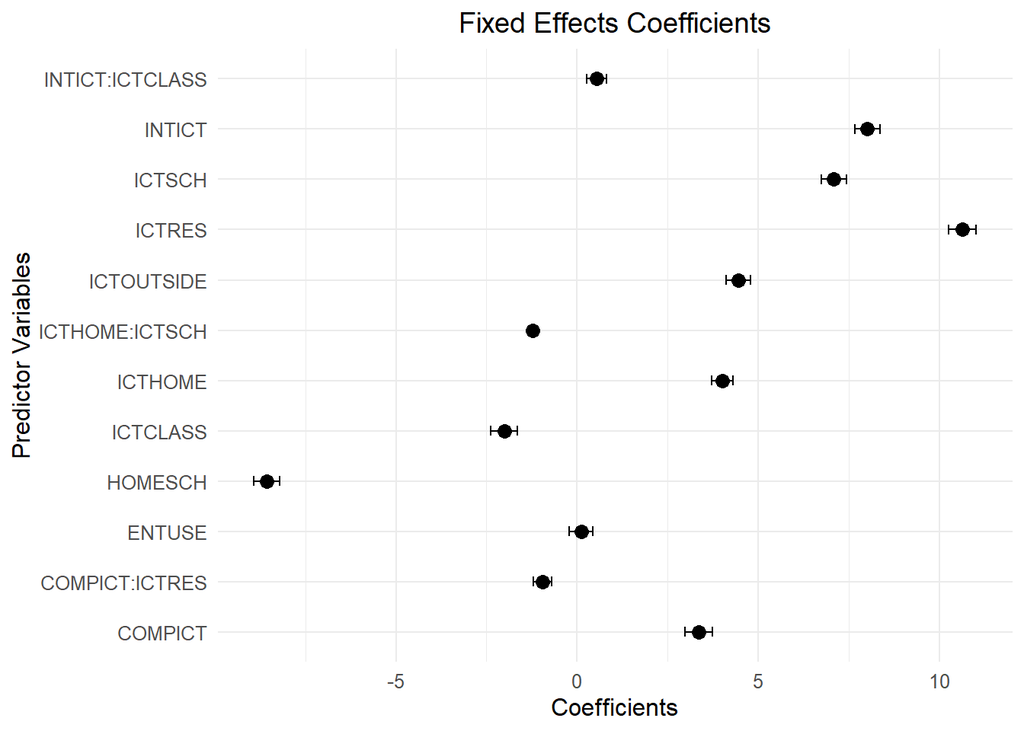

## Random Effect Plot

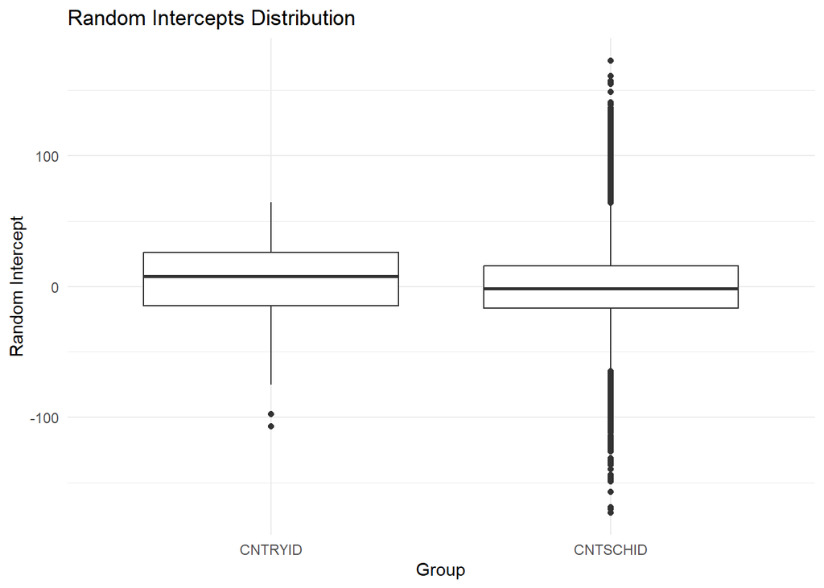

## Model Comparison Plot

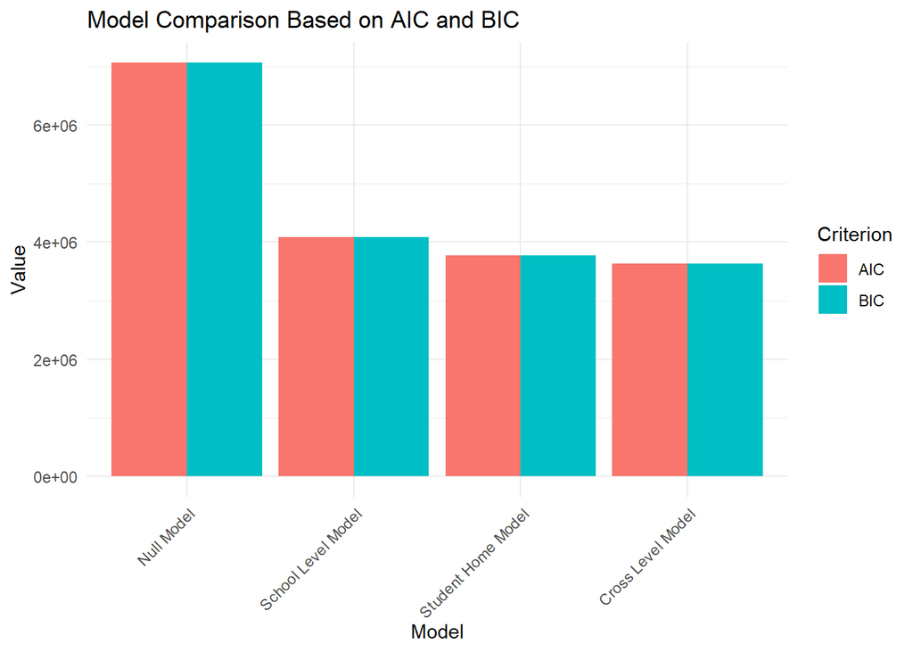

## Assumptions

### 1. Linearity

Residuals against the fitted values to check for any systematic patterns:

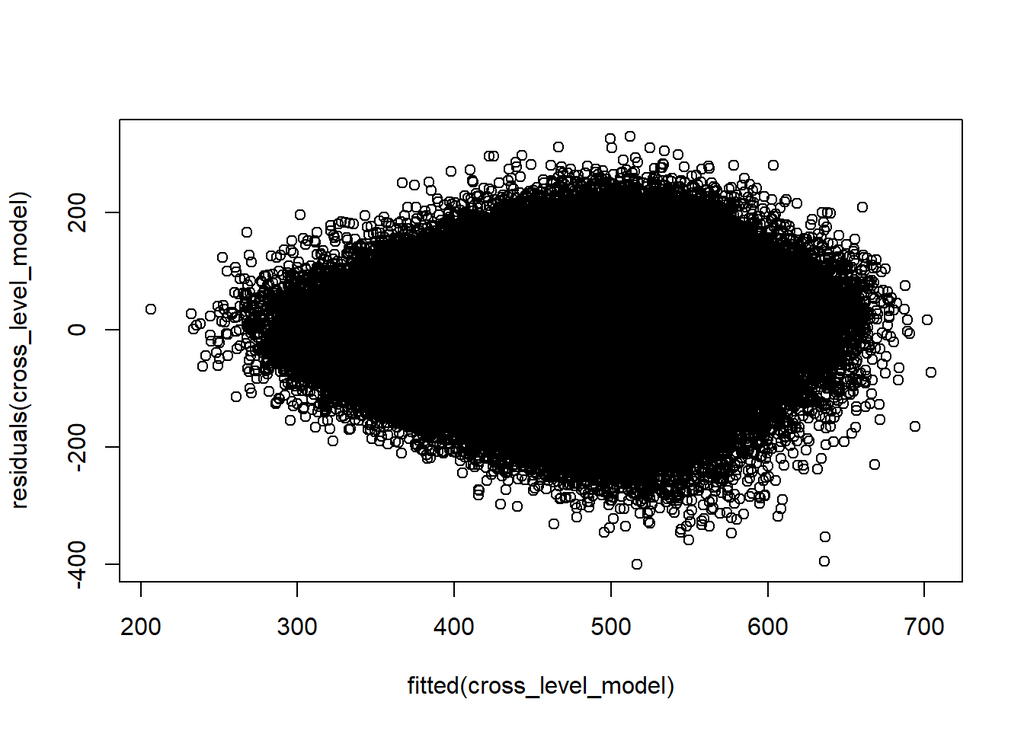

### 2. Independence

Since I am using clustered data, I am aware of the inherent dependence within groups (e.g., students within schools). By including random effects for these clusters, I’ve addressed this issue in the model.

### 3. Homoscedasticity

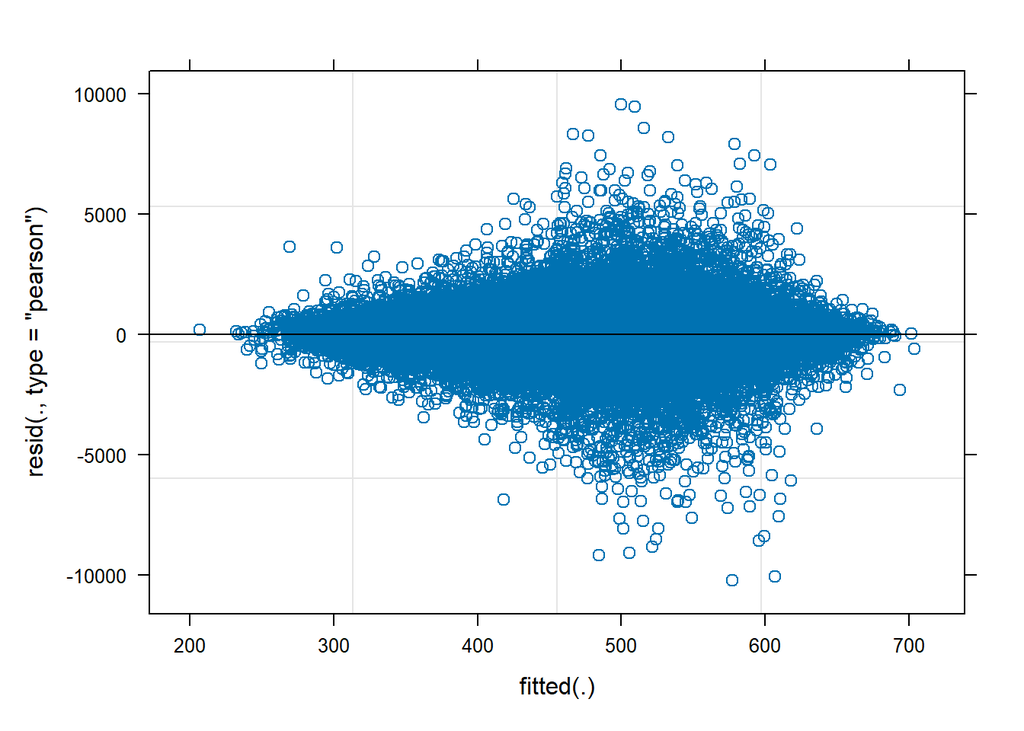

### 4. Normality of Residuals

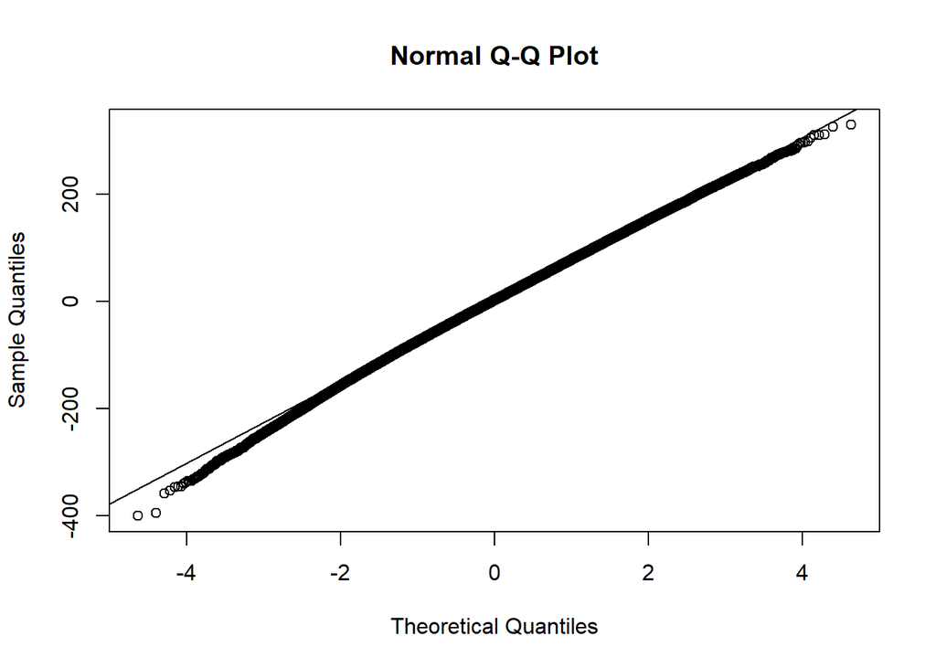

### 5. Multicollinearity

1. A VIF value of 1 means no correlation among the corresponding predictor and the others.
2. A VIF value between 1 and 5 usually indicates moderate correlation.
3. A VIF value greater than 5 (some researchers use a threshold of 10) might suggest a problematic amount of collinearity.

```
Call:
lm(formula = formula_lm, data = student_data, weights = student_data$W_FSTUWT)

Weighted Residuals:
    Min      1Q  Median      3Q     Max
-9818.5  -228.4   -15.2   194.4 11561.7

Coefficients:
             Estimate Std. Error t value Pr(>|t|)
(Intercept) 524.45910    0.84210 622.801  < 2e-16 ***
ICTHOME      -1.94197    0.09811 -19.794  < 2e-16 ***
COMPICT       2.30405    0.21856  10.542  < 2e-16 ***
INTICT       12.34640    0.21078  58.575  < 2e-16 ***
HOMESCH     -13.38861    0.20162 -66.405  < 2e-16 ***
ICTOUTSIDE    3.56550    0.19299  18.475  < 2e-16 ***
ICTSCH       -1.81063    0.07571 -23.914  < 2e-16 ***
ICTRES       31.97738    0.20495 156.026  < 2e-16 ***
ICTCLASS      1.76607    0.20248   8.722  < 2e-16 ***
ENTUSE       -0.73985    0.19207  -3.852 0.000117 ***
---
Signif. codes:  0 '***' 0.001 '**' 0.01 '*' 0.05 '.' 0.1 ' ' 1

Residual standard error: 639 on 283357 degrees of freedom
  (328637 observations deleted due to missingness)
Multiple R-squared:  0.1387,    Adjusted R-squared:  0.1387
F-statistic:  5072 on 9 and 283357 DF,  p-value: < 2.2e-16
```

```
   ICTHOME    COMPICT     INTICT    HOMESCH ICTOUTSIDE     ICTSCH     ICTRES
  1.775774   1.490780   1.473719   1.487566   1.331405   1.256578   1.656782
  ICTCLASS     ENTUSE
  1.272101   1.451696
```

The examination of multicollinearity for the predictors in the model revealed no serious concerns. The VIF values for all predictors were well below the commonly used threshold of 5, indicating a moderate level of correlation among the predictors. Specifically, the VIF values were as follows: ICTHOME = 1.78, COMPICT = 1.49, INTICT = 1.47, HOMESCH = 1.49, ICTOUTSIDE = 1.33, ICTSCH = 1.26, ICTRES = 1.66, ICTCLASS = 1.27, and ENTUSE = 1.45. These values suggest that the variables are not highly collinear, and therefore, no adjustments to the model were deemed necessary due to multicollinearity.

### 6. Influential Observations

In linear regression, Cook’s distance is a commonly used diagnostic for identifying observations that might be overly influential.

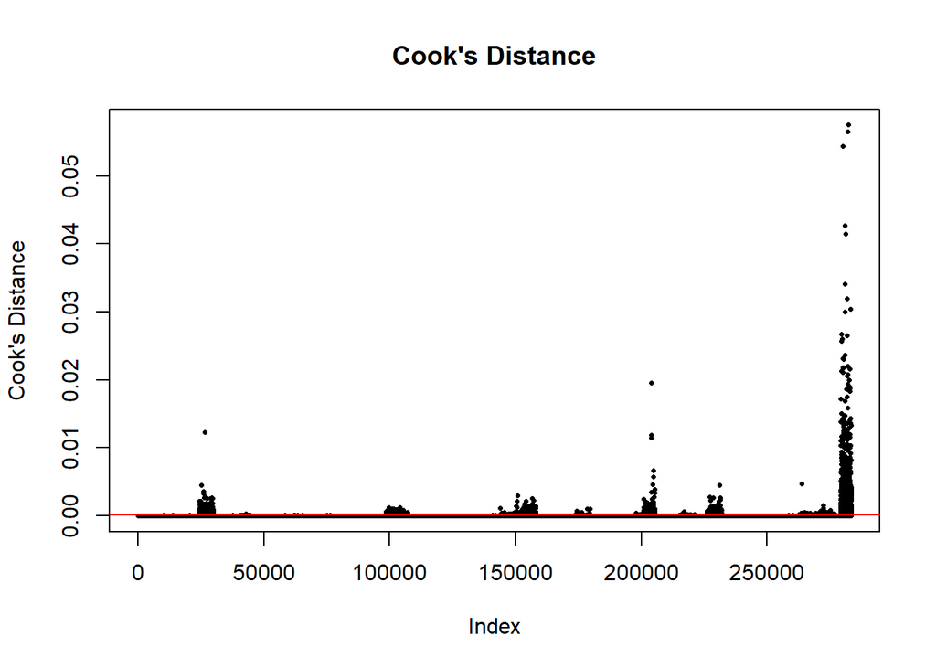

```
[1] "Number of Influential Observations: 7425"
```

```
[1] "Top 10 Cook's Distance Values:"
```

```
    605205     604993     602896     603740     604162     603579     604555
0.05749234 0.05654274 0.05434838 0.04274333 0.04150414 0.03406484 0.03192001
    606194     603562     602248
0.03042951 0.02998266 0.02674287
```

Given that I have a total of 612004 observations, the 7425 influential observations constitute approximately 1.21% of the dataset. In this context, the number may not be as concerning as it might initially appear, especially when considering the relatively low Cook’s distance values for the top ten influential observations.

In general, Cook’s distance values below 0.1 are often considered to be of low concern, as they suggest a minimal influence on the model’s estimates. The values I’ve provided are indeed below this threshold.

## Mathematical Expression:

### 1. Student Home Model

$$y_{ij} = \beta_0 + \beta_1 \cdot \text{{ICTHOME}}_{ij} + \beta_2 \cdot
\text{{COMPICT}}_{ij} + \beta_3 \cdot \text{{INTICT}}_{ij} + \beta_4
\cdot \text{{HOMESCH}}_{ij} + \beta_5 \cdot \text{{ICTOUTSIDE}}_{ij} +
u_j + \epsilon_{ij}$$

#### Explanation:

- **Outcome Variable ($y_{ij}$)**: The reading score for student $i$ in country $j$.
- **Fixed Effects**:
  - $\beta_0$: The intercept.
  - $\beta_1, \beta_2, \beta_3, \beta_4, \beta_5$: Coefficients for the predictors ICTHOME, COMPICT, INTICT, HOMESCH, ICTOUTSIDE, respectively.
- **Random Effects**:
  - $u_j$: Random effect for country $j$.
- **Error Term**:
  - $\epsilon_{ij}$: Residual error for student $i$ in country $j$.

### 2. School Model

#### Mathematical Expression:

$$y_{ik} = \beta_0 + \beta_1 \cdot \text{{ICTSCH}}_{ik} + \beta_2 \cdot
\text{{ICTRES}}_{ik} + \beta_3 \cdot \text{{ICTCLASS}}_{ik} + \beta_4
\cdot \text{{ENTUSE}}_{ik} + v_k + \epsilon_{ik}$$

#### Explanation:

- **Outcome Variable ($y_{ik}$)**: The reading score for student $i$ in school $k$.
- **Fixed Effects**:
  - $\beta_0$: The intercept.
  - $\beta_1, \beta_2, \beta_3, \beta_4$: Coefficients for the predictors ICTSCH, ICTRES, ICTCLASS, ENTUSE, respectively.
- **Random Effects**:
  - $v_k$: Random effect for school $k$.
- **Error Term**:
  - $\epsilon_{ik}$: Residual error for student $i$ in school $k$.

### 3. Cross Level Model

#### Mathematical Expression:

$$\begin{align*}
y_{ijk} = \beta_0 &+ \beta_1 \cdot \text{{ICTHOME}}_{ijk} + \beta_2
\cdot \text{{COMPICT}}_{ijk} + \beta_3 \cdot \text{{INTICT}}_{ijk} +
\beta_4 \cdot \text{{HOMESCH}}_{ijk} + \beta_5 \cdot
\text{{ICTOUTSIDE}}_{ijk} \\
&+ \beta_6 \cdot \text{{ICTSCH}}_{ijk} + \beta_7 \cdot
\text{{ICTRES}}_{ijk} + \beta_8 \cdot \text{{ICTCLASS}}_{ijk} + \beta_9
\cdot \text{{ENTUSE}}_{ijk} + \beta_{10} \cdot (\text{{ICTHOME}}_{ijk}
\times \text{{ICTSCH}}_{ijk}) \\
&+ \beta_{11} \cdot (\text{{COMPICT}}_{ijk} \times
\text{{ICTRES}}_{ijk}) + \beta_{12} \cdot (\text{{INTICT}}_{ijk} \times
\text{{ICTCLASS}}_{ijk}) + u_k + v_j + \epsilon_{ijk}
\end{align*}$$

#### Explanation:

- **Outcome Variable ($y_{ijk}$)**: The reading score for student $i$ in school $k$ and country $j$.
- **Fixed Effects**:
  - $\beta_0$: The intercept.
  - $\beta_1$ to $\beta_9$: Coefficients for the main effects.
  - $\beta_{10}$ to $\beta_{12}$: Coefficients for the interaction effects.
- **Random Effects**:
  - $u_k$: Random effect for school $k$.
  - $v_j$: Random effect for country $j$.
- **Error Term**:
  - $\epsilon_{ijk}$: Residual error for student $i$ in school $k$ and country $j$.

These models reflect different levels of complexity, with the Student Home Model focusing on country-level effects, the School Model on school-level effects, and the Cross Level Model incorporating interactions and both school and country-level effects.

### Calculate Descriptive Statistics

```
    CNTRYID          CNT               CNTSCHID           CNTSTUID
 Min.   :  8.0   Length:612004      Min.   :  800002   Min.   :  800001
 1st Qu.:203.0   Class :character   1st Qu.:20300206   1st Qu.:20304807
 Median :422.0   Mode  :character   Median :42200308   Median :42206160
 Mean   :448.9                      Mean   :44893542   Mean   :44900230
 3rd Qu.:703.0                      3rd Qu.:70300148   3rd Qu.:70303074
 Max.   :983.0                      Max.   :98300806   Max.   :98329122

      OECD           ICTHOME           ICTSCH           ICTRES
 Min.   :0.0000   Min.   : 0.00    Min.   : 0.0     Min.   :-4.095
 1st Qu.:0.0000   1st Qu.: 6.00    1st Qu.: 5.0     1st Qu.:-0.973
 Median :0.0000   Median : 8.00    Median : 6.0     Median :-0.349
 Mean   :0.4813   Mean   : 7.85    Mean   : 6.2     Mean   :-0.358
 3rd Qu.:1.0000   3rd Qu.:10.00    3rd Qu.: 8.0     3rd Qu.: 0.333
 Max.   :1.0000   Max.   :11.00    Max.   :10.0     Max.   : 4.007
                  NA's   :249475   NA's   :256547   NA's   :15676
     ENTUSE          HOMESCH           USESCH           INTICT
 Min.   :-3.59    Min.   :-2.70    Min.   :-2.54    Min.   :-3.02
 1st Qu.:-0.44    1st Qu.:-0.38    1st Qu.:-0.55    1st Qu.:-0.57
 Median :-0.05    Median : 0.07    Median : 0.11    Median :-0.02
 Mean   : 0.02    Mean   : 0.09    Mean   : 0.02    Mean   : 0.00
 3rd Qu.: 0.42    3rd Qu.: 0.51    3rd Qu.: 0.65    3rd Qu.: 0.49
 Max.   : 4.31    Max.   : 3.32    Max.   : 3.35    Max.   : 2.77
 NA's   :271459   NA's   :288643   NA's   :298901   NA's   :292761
    COMPICT           AUTICT          ICTCLASS        ICTOUTSIDE
 Min.   :-2.62    Min.   :-2.51    Min.   :-1.22    Min.   :-1.30
 1st Qu.:-0.64    1st Qu.:-0.60    1st Qu.:-1.22    1st Qu.:-0.82
 Median : 0.05    Median : 0.10    Median :-0.02    Median : 0.11
 Mean   :-0.01    Mean   :-0.01    Mean   :-0.06    Mean   : 0.05
 3rd Qu.: 0.42    3rd Qu.: 0.33    3rd Qu.: 0.61    3rd Qu.: 0.69
 Max.   : 2.58    Max.   : 2.03    Max.   : 2.44    Max.   : 2.50
 NA's   :299011   NA's   :306205   NA's   :275263   NA's   :283481
    W_FSTUWT           PV1READ         PV2READ          PV3READ
 Min.   :   1.000   Min.   :  0.0   Min.   : 28.73   Min.   :  0.341
 1st Qu.:   4.946   1st Qu.:378.1   1st Qu.:378.12   1st Qu.:378.404
 Median :  11.133   Median :455.7   Median :455.75   Median :455.644
 Mean   :  46.857   Mean   :456.1   Mean   :456.12   Mean   :456.069
 3rd Qu.:  43.973   3rd Qu.:533.5   3rd Qu.:533.32   3rd Qu.:533.232
 Max.   :2946.134   Max.   :887.7   Max.   :898.48   Max.   :888.223
                    NA's   :5377    NA's   :5377     NA's   :5377
    PV4READ         PV5READ          PV6READ          PV7READ
 Min.   :  0.0   Min.   : 16.89   Min.   : 31.95   Min.   : 14.16
 1st Qu.:378.4   1st Qu.:378.34   1st Qu.:378.21   1st Qu.:378.43
 Median :455.5   Median :455.69   Median :455.80   Median :455.70
 Mean   :456.1   Mean   :456.17   Mean   :456.20   Mean   :456.12
 3rd Qu.:533.5   3rd Qu.:533.15   3rd Qu.:533.29   3rd Qu.:533.55
 Max.   :885.3   Max.   :885.24   Max.   :873.89   Max.   :890.93
 NA's   :5377    NA's   :5377     NA's   :5377     NA's   :5377
    PV8READ         PV9READ         PV10READ
 Min.   :  0.0   Min.   :  0.0   Min.   :  0.0
 1st Qu.:378.2   1st Qu.:378.2   1st Qu.:378.3
 Median :455.7   Median :455.8   Median :455.5
 Mean   :456.0   Mean   :456.1   Mean   :456.1
 3rd Qu.:533.3   3rd Qu.:533.3   3rd Qu.:533.3
 Max.   :928.7   Max.   :862.3   Max.   :884.0
 NA's   :5377    NA's   :5377    NA's   :5377
```

```
                   Mean  Median Standard.Deviation     Min     Max
ICTHOME     7.845915775  8.0000          2.4648216  0.0000 11.0000
ICTSCH      6.204168155  6.0000          2.5660236  0.0000 10.0000
OECD        0.481250123  0.0000          0.4996487  0.0000  1.0000
ICTRES     -0.357932280 -0.3490          1.1468245 -4.0951  4.0072
ENTUSE      0.021694174 -0.0509          1.0904684 -3.5940  4.3149
HOMESCH     0.091826060  0.0708          1.0399151 -2.6977  3.3154
INTICT      0.001817970 -0.0186          1.0244343 -3.0242  2.7721
COMPICT    -0.005148242  0.0537          0.9853114 -2.6188  2.5782
ICTCLASS   -0.056170745 -0.0241          1.0157652 -1.2188  2.4394
ICTOUTSIDE  0.046603617  0.1093          1.0401477 -1.3048  2.4969
           Missing.Values
ICTHOME            249475
ICTSCH             256547
OECD                    0
ICTRES              15676
ENTUSE             271459
HOMESCH            288643
INTICT             292761
COMPICT            299011
ICTCLASS           275263
ICTOUTSIDE         283481
```

### Weighted Descriptive Statistics

```
[1] "Mean:  446.609673088934"
```

```
[1] "SD:  110.697561397199"
```

```
[1] "Min:  9.2078"
```

```
[1] "Max:  888.4681"
```

### Weighted Descriptive Statistics for Other Variables

```
       Variable         Mean Standard.Deviation  Median     Min     Max
50%     ICTHOME  7.516604963          2.6772051  8.0000  0.0000 11.0000
50%1     ICTSCH  6.004766334          2.7373508  6.0000  0.0000 10.0000
50%2     ICTRES -0.774365890          1.2704613 -0.6231 -4.0951  4.0072
50%3       OECD  0.473416518          0.4992928  0.0000  0.0000  1.0000
50%4     ENTUSE -0.014744662          1.1340117 -0.0755 -3.5940  4.3149
50%5    HOMESCH  0.102981921          1.0870664  0.1172 -2.6977  3.3154
50%6     INTICT  0.003806167          1.0371400 -0.0186 -3.0242  2.7721
50%7    COMPICT -0.032890626          1.0038135  0.0537 -2.6188  2.5782
50%8   ICTCLASS -0.062703623          0.9954545 -0.0096 -1.2188  2.4394
50%9 ICTOUTSIDE  0.073332795          1.0614724  0.2105 -1.3048  2.4969
```

### Sample and Weighted Sample

1. Sample Statistics: These are the basic descriptive statistics without considering the weights. You can calculate them using R’s basic functions like mean, sd, median, etc.
2. Weighted Sample Statistics: These are the statistics you’ve calculated that take into account the weighting variable “W_FSTUWT.”

```
    Variable         Mean Standard.Deviation  Median     Min     Max
1    ICTHOME  7.845915775          2.4648216  8.0000  0.0000 11.0000
2     ICTSCH  6.204168155          2.5660236  6.0000  0.0000 10.0000
3     ICTRES -0.357932280          1.1468245 -0.3490 -4.0951  4.0072
4     ENTUSE  0.021694174          1.0904684 -0.0509 -3.5940  4.3149
5    HOMESCH  0.091826060          1.0399151  0.0708 -2.6977  3.3154
6     INTICT  0.001817970          1.0244343 -0.0186 -3.0242  2.7721
7    COMPICT -0.005148242          0.9853114  0.0537 -2.6188  2.5782
8   ICTCLASS -0.056170745          1.0157652 -0.0241 -1.2188  2.4394
9 ICTOUTSIDE  0.046603617          1.0401477  0.1093 -1.3048  2.4969
```

### Actual Sample Size

The actual sample size is simply the count of non-missing observations for each variable. You can calculate it using the following code:

```
   ICTHOME     ICTSCH       OECD     ICTRES     ENTUSE    HOMESCH     INTICT
    362529     355457     612004     596328     340545     323361     319243
   COMPICT   ICTCLASS ICTOUTSIDE
    312993     336741     328523
```

### Pairwise Correlation

```
           ICTHOME   ICTSCH    ICTRES    ENTUSE    HOMESCH   INTICT
ICTHOME    "1"       "0.38***" "0.54***" "0.17***" "0.14***" "0.08***"
ICTSCH     "0.38***" "1"       "0.22***" "0.09***" "0.19***" "0.01***"
ICTRES     "0.54***" "0.22***" "1"       "0.15***" "0.09***" "0.15***"
ENTUSE     "0.17***" "0.09***" "0.15***" "1"       "0.46***" "0.33***"
HOMESCH    "0.14***" "0.19***" "0.09***" "0.46***" "1"       "0.19***"
INTICT     "0.08***" "0.01***" "0.15***" "0.33***" "0.19***" "1"
COMPICT    "0.13***" "0.05***" "0.16***" "0.32***" "0.22***" "0.52***"
ICTCLASS   "0.12***" "0.21***" "0.14***" "0.08***" "0.17***" "0.05***"
ICTOUTSIDE "0.09***" "0.14***" "0.09***" "0.13***" "0.3***"  "0.08***"
           COMPICT   ICTCLASS  ICTOUTSIDE
ICTHOME    "0.13***" "0.12***" "0.09***"
ICTSCH     "0.05***" "0.21***" "0.14***"
ICTRES     "0.16***" "0.14***" "0.09***"
ENTUSE     "0.32***" "0.08***" "0.13***"
HOMESCH    "0.22***" "0.17***" "0.3***"
INTICT     "0.52***" "0.05***" "0.08***"
COMPICT    "1"       "0.07***" "0.1***"
ICTCLASS   "0.07***" "1"       "0.43***"
ICTOUTSIDE "0.1***"  "0.43***" "1"
```

### Weighted Sample Size

This considers the weighting of each observation and adds up the weights for the non-missing observations. It represents the “effective” sample size, taking into account the relative importance or frequency of different types of observations in the population you’re studying.

```
   ICTHOME     ICTSCH       OECD     ICTRES     ENTUSE    HOMESCH     INTICT
  15928853   15598512   28676450   27887223   15379114   14286752   14534014
   COMPICT   ICTCLASS ICTOUTSIDE
  14283036   15359596   15032331
```

### Total Students by Country

```
   CNTRYID Total_Students Weighted_Sample_Size CNT
1        8           6359            27962.733 ALB
2       31           6827            20271.198 QAZ
3       32          11975           566485.562 ARG
4       36          14273           257778.735 AUS
5       40           6802            75077.256 AUT
6       56           8475           118024.814 BEL
7       70           6480            28842.744 BIH
8       76          10691          2036860.645 BRA
9       96           6828             6899.001 BRN
10     100           5294            47851.470 BGR
11     112           5803            78333.031 BLR
12     124          22653           335196.981 CAN
13     152           7621           213832.110 CHL
14     158           7243           226698.249 TAP
```

[output cut: 66 more lines]

### Total Schools by Country (With Weighted Sample Size)

```
   CNTRYID Total_Schools Weighted_Sample_Size CNT
1        8           327            27962.733 ALB
2       31           197            20271.198 QAZ
3       32           455           566485.562 ARG
4       36           763           257778.735 AUS
5       40           291            75077.256 AUT
6       56           288           118024.814 BEL
7       70           213            28842.744 BIH
8       76           597          2036860.645 BRA
9       96            55             6899.001 BRN
10     100           197            47851.470 BGR
11     112           234            78333.031 BLR
12     124           821           335196.981 CAN
13     152           254           213832.110 CHL
14     158           192           226698.249 TAP
```

[output cut: 66 more lines]

### Students by Schools

```
# A tibble: 1 × 3
  Mean_Students_Per_School Min_Students_Per_School Max_Students_Per_School
                     <dbl>                   <int>                   <int>
1                     27.9                       1                     491
```

### Total Sample.

```
  Total_Countries Total_Schools Total_Students
1              80         21903         612004
```

### OECD Countries

```
   Category   OECD Partner
1 Countries     37      43
2   Schools  11327   10576
3  Students 294527  317477
```

### Plot 1: ICT Usage Across Different Environments

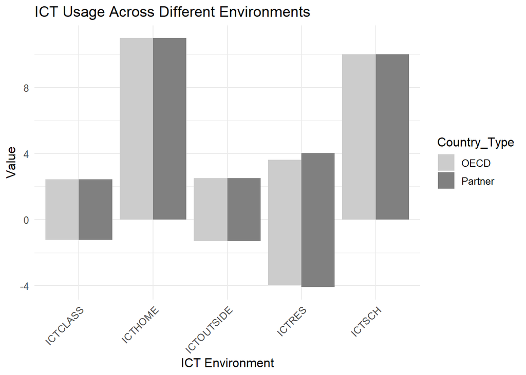

### Plot 2: Reading Performance Across Countries

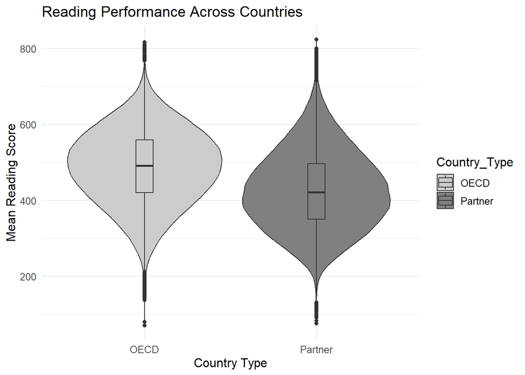

### Plot 3: Relationship Between Home ICT Usage and Reading Performance

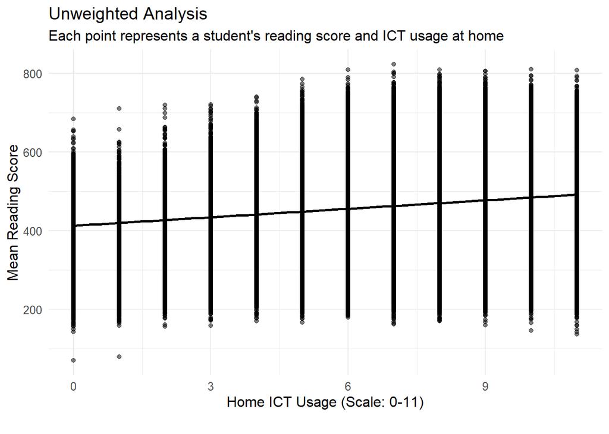

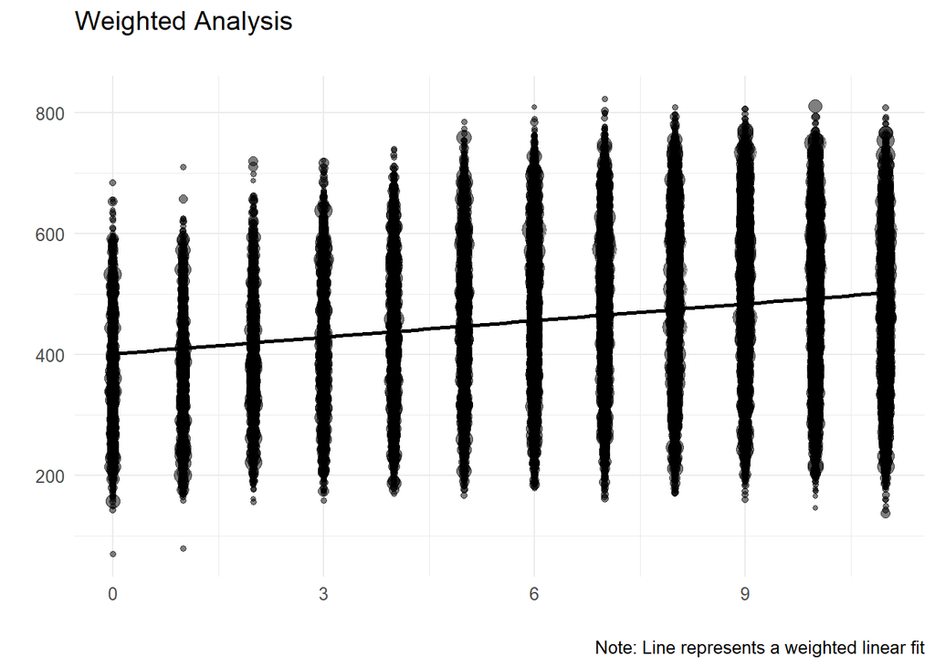

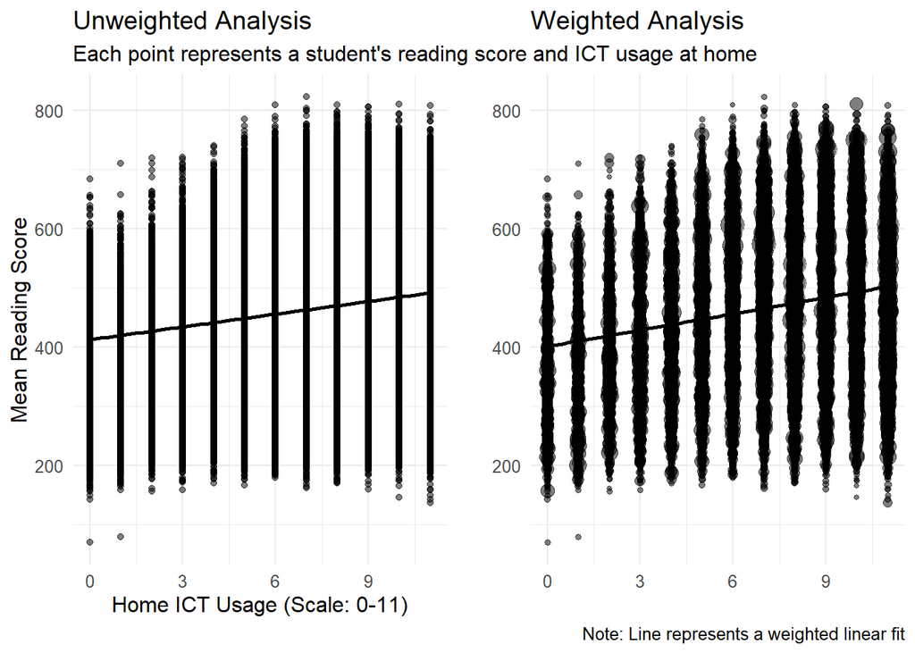